# 【20220421回家作業】

### 自行決定平常交易策略的賺賠比、勝率 (要合理)，劃出不同下注比例的理論損益(橫軸)。分別有下1~30次的損益曲線圖，show出最佳下注比例 (通常一定會有槓桿)，做個分析。

圖1-1

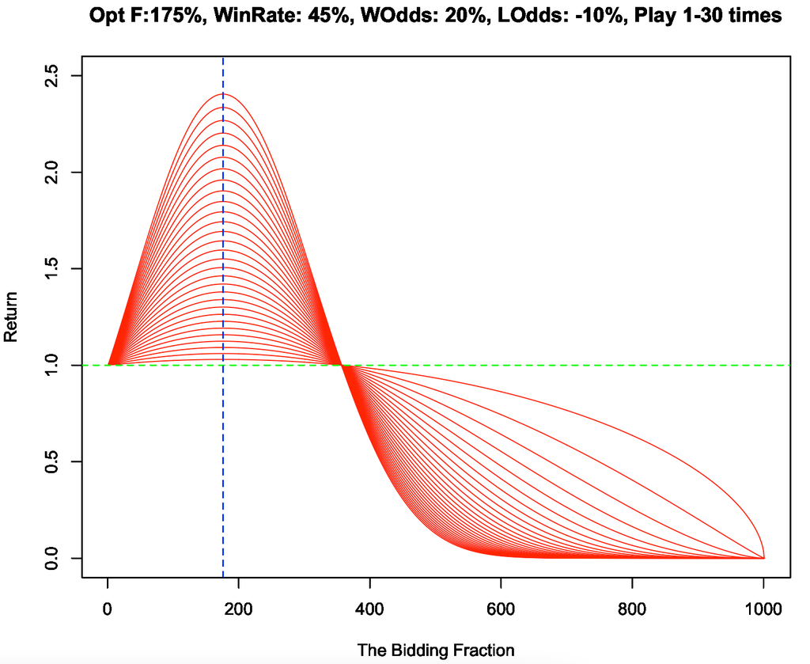

圖1-2

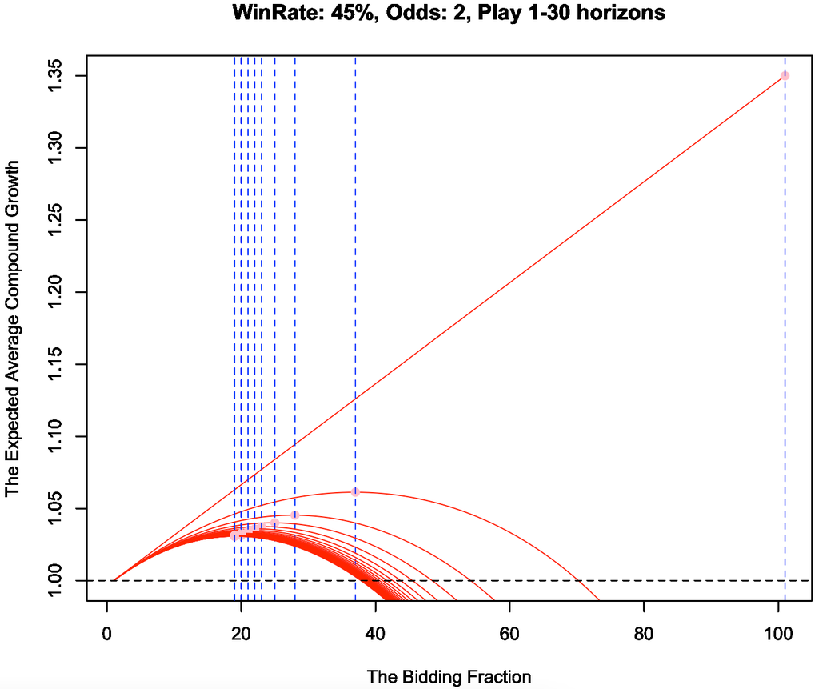

圖1-3

[figure not shown]

## 分析結果

一般化的凱利公式

(圖1-1)(圖1-3黃色)

期望平均複合成長率 (EACG)

(圖1-2)(圖1-3綠色)

方法

勝率為𝑝，贏的賠率為b1，輸的賠率為b2 (b2 > 0)將凱利公式中的賺賠比一般化。原來的賺賠比為b，改善為｜獲利(b1)/虧損(b2)｜。

勝率為p，賠率為𝑏的賭局玩𝑇次，每次下注資金比例f ，對每一種路徑(贏𝑘次，輸𝑇 − 𝑘次)，計算每一步成長率(共𝑇步)的乘積以及其幾何平均數。再將每一種路徑成長率的幾何平均數平均(算術平均)起來。

公式

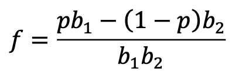

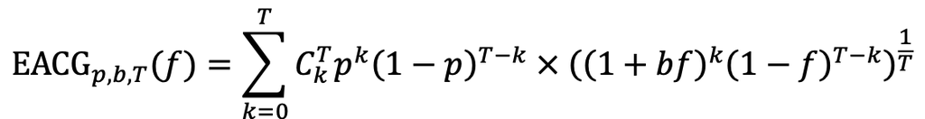

實驗設定

勝率45% ，贏20%，輸-10%，賺賠比2

勝率45% ，賠率（贏:輸）2:1，賺賠比2

觀察結果

下注比例

固定比例。

隨著回合數增多，最佳下注比例保持不變，為175%

浮動比例。

累計損益

隨著回合數增多，收益逐步微小穩定地提升

隨著回合數增多，資產成長率會隨著下注比例逐漸收斂至一個穩定數值。